# US Name

Estimate SO2 emission as a function of period and others variables

# Description

- Effect of credit supply

## Variables

### Target

SO2 emission

### Features

- credit_supply
- credit_supply_long_term
- credit_supply*short* term
- share_ big bank_loan
- share_big_loan

## Complementary information

Title: Add credit supply Use the new variables such as credit supply in the model to interact with FYP and period Add tfp?

# Metadata

- Key: 171_Pollution_and_Credit_Constraint
- Epic: Models
- US: Credit supply
- Task tag: #data-analysis, #credit-supply
- Analytics reports:

# Input Cloud Storage

## Table/file

**Name**

- https://github.com/thomaspernet/pollution_credit_constraint/blob/master/01_data_preprocessing/02_transform_tables/00_credit_constraint_industry.md

**Github**

- fin_dep_pollution_baseline_industry

# Load tables

Since we load the data as a Pandas DataFrame, we want to pass the `dtypes`. We load the schema from Glue to guess the types

|  | Name | Type | Comment |
| --- | --- | --- | --- |
| 0 | year | string |  |
| 1 | period | varchar(5) |  |
| 2 | province_en | string |  |
| 3 | cityen | string |  |
| 4 | geocode4_corr | string |  |
| ... | ... | ... | ... |
| 95 | dominated_sales_for_i | map<double,boolean> |  |
| 96 | dominated_capital_for_i | map<double,boolean> |  |
| 97 | fe_c_i | bigint |  |
| 98 | fe_t_i | bigint |  |
| 99 | fe_c_t | bigint |  |

100 rows × 3 columns

## Schema Latex table

To rename a variable, please use the following template:

```
{
    'old':'XX',
    'new':'XX_1'
    }
```

if you need to pass a latex format with `\`, you need to duplicate it for instance, `\text` becomes `\text:

```
{
    'old':'working\_capital\_i',
    'new':'\\text{working capital}_i'
    }
```

Then add it to the key `to_rename`

```
 Hlavac, Marek (2018). stargazer: Well-Formatted Regression and Summary Statistics Tables.
 R package version 5.2.2. https://CRAN.R-project.org/package=stargazer
```

| year | period | province_en | cityen | geocode4_corr | tcz | spz | ind2 | short | polluted_d50i | ... | dominated_sales_for_i | dominated_capital_for_i | fe_c_i | fe_t_i | fe_c_t | trend | fe_p_t | fe_p_i | fin_dev | lag_fin_dev |
| --- | --- | --- | --- | --- | --- | --- | --- | --- | --- | --- | --- | --- | --- | --- | --- | --- | --- | --- | --- | --- |
| 2001 | FALSE | Anhui | Anqing | 3408 | 0 | 0 | 13 | Processing foods | ABOVE | ... | {0.5=true, 0.9=false, 0.75=true, 0.95=false} | {0.5=true, 0.9=false, 0.75=false, 0.95=false} | 2273 | 88 | 915 | 4 | 4 | 1 | 0.46564 | 0.45456 |
| 2003 | FALSE | Anhui | Huainan | 3404 | 0 | 0 | 13 | Processing foods | ABOVE | ... | {0.5=false, 0.9=false, 0.75=false, 0.95=false} | {0.5=true, 0.9=true, 0.75=true, 0.95=true} | 2199 | 145 | 882 | 6 | 6 | 1 | 0.46861 | 0.46148 |
| 2001 | FALSE | Anhui | Wuhu | 3402 | 1 | 1 | 13 | Processing foods | ABOVE | ... | {0.5=false, 0.9=true, 0.75=true, 0.95=true} | {0.5=true, 0.9=true, 0.75=true, 0.95=false} | 2147 | 88 | 862 | 4 | 4 | 1 | 0.46564 | 0.45456 |
| 2005 | FALSE | Anhui | Bengbu | 3403 | 0 | 0 | 13 | Processing foods | ABOVE | ... | {0.5=true, 0.9=true, 0.75=false, 0.95=false} | {0.5=true, 0.9=true, 0.75=true, 0.95=true} | 2174 | 203 | 875 | 8 | 8 | 1 | NA | 0.47134 |
| 2005 | FALSE | Anhui | Fuyang | 3412 | 0 | 0 | 13 | Processing foods | ABOVE | ... | {0.5=true, 0.9=false, 0.75=false, 0.95=false} | {0.5=false, 0.9=false, 0.75=false, 0.95=false} | 2342 | 203 | 946 | 8 | 8 | 1 | NA | 0.47134 |
| 2001 | FALSE | Anhui | Bozhou | 3416 | 0 | 0 | 13 | Processing foods | ABOVE | ... | {0.5=false, 0.9=false, 0.75=false, 0.95=false} | {0.5=true, 0.9=false, 0.75=true, 0.95=false} | 2392 | 88 | 965 | 4 | 4 | 1 | 0.46564 | 0.45456 |

Aggregate at the province-industry-year level

| province_en | ind2 | year | period | fe_p_i | fe_t_i | fe_p_t | tso2 | tcod | twaste_water | ... | employment | capital | target_reduction_so2_p | target_reduction_co2_p | lag_credit_supply | lag_credit_supply_long_term | fin_dev | lag_fin_dev | credit_constraint | year1 |
| --- | --- | --- | --- | --- | --- | --- | --- | --- | --- | --- | --- | --- | --- | --- | --- | --- | --- | --- | --- | --- |
| Anhui | 13 | 2001 | FALSE | 1 | 88 | 4 | 1398456 | 1431675.1 | 4497401 | ... | 26970 | 1247712 | 0.23 | 0.65 | 0.67769 | 0.17947 | 0.46564 | 0.45456 | -0.47 | 2001 |
| Anhui | 13 | 1998 | FALSE | 1 | 1 | 1 | 469673 | 3310501.0 | 1929756 | ... | 36357 | 720409 | 0.23 | 0.65 | 0.58065 | 0.11785 | 0.38202 | 0.43303 | -0.47 | 1998 |
| Anhui | 13 | 1999 | FALSE | 1 | 30 | 2 | 924790 | 1398194.0 | 1891661 | ... | 34438 | 1180475 | 0.23 | 0.65 | 0.61749 | 0.12280 | 0.37900 | 0.38202 | -0.47 | 1999 |
| Anhui | 13 | 2000 | FALSE | 1 | 59 | 3 | 1071436 | 1534712.0 | 2599504 | ... | 32534 | 1226724 | 0.23 | 0.65 | 0.59567 | 0.11632 | 0.45456 | 0.37900 | -0.47 | 2000 |
| Anhui | 13 | 2002 | FALSE | 1 | 116 | 5 | 531884 | 816333.9 | 2301020 | ... | 3064 | 74066 | 0.23 | 0.65 | 0.72964 | 0.20348 | 0.46148 | 0.46564 | -0.47 | 2002 |
| Anhui | 13 | 2003 | FALSE | 1 | 145 | 6 | 1459373 | 1728301.1 | 5968583 | ... | 39179 | 1711543 | 0.23 | 0.65 | 0.74632 | 0.20580 | 0.46861 | 0.46148 | -0.47 | 2003 |

## Variables Definition

1. credit_supply: Province-year supply all loans over GDP
2. credit_supply_long_term: Province-year supply long term loans over GDP
3. fin_dev: Share of non-4-SOCBs' share in credit

## Table 1:Financial development over time

$$ \begin{aligned} \text{$S O 2_{c k t}=\alpha$ Financial Dependencies $_{k} \times \text{credit supply}_{pt} +\beta X_{c k t}+\mu_{c t}+\gamma_{k t}+\delta_{c k}+\epsilon_{c k t}$} \end{aligned} $$$$ \begin{aligned} \text{$S O 2_{c k t}=\alpha$ Financial Dependencies $_{k} \times \text{Fin.Dev}_{pt} + +\beta X_{c k t}+\mu_{c t}+\gamma_{k t}+\delta_{c k}+\epsilon_{c k t}$} \end{aligned} $$

1. Table 1: SO2 emission reduction, credit supply and financial development
   1. All loan interacted with credit constraint
   2. Long term loan with credit constraint
   3. Financial development with credit constraint

**Message**

- An increase of supply of credit or improvement of financial development (deregulation of banking sectors) is beneficial for the reduction of SO2 emission
  - Deregulation has a stronger effect on constraint sectors than non-constraint → backed by the theory that credit openness is more beneficial for constraint sectors

### City level

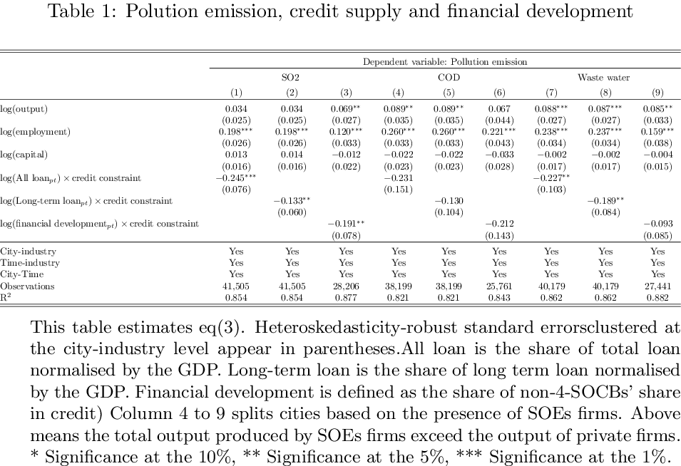

## Table 2: heterogeneous effect: SOE vs Private

City ownership are available for the following variables:

- output
- capital
- employment
- sales

**How is it constructed**

- city ownership public vs private
  - Aggregate output by ownership and city
  - A given city will have SOE asset tangibility and PRIVATE asset tangibility [output, employment, capital and sales]
  - If asset tangibility SOE above Private then city is dominated by SOE

Notebook reference: https://github.com/thomaspernet/Financial_dependency_pollution/blob/master/01_data_preprocessing/02_transform_tables/07_dominated_city_ownership.md

Industrial are available for the following variables:

- output
- capital
- employment
- sales

**Industrial size effect**

- Change computation large vs small industry
  - Compute the median (percentile) within a city taking all firms
  - Compute the median (percentile) within a city-industry taking all firms within the industry
  - For instance, Shanghai has 3 sectors, compute the median for Shanghai, and 3 median for each sector

Notebook reference: https://github.com/thomaspernet/Financial_dependency_pollution/blob/master/01_data_preprocessing/02_transform_tables/08_dominated_industry_ownership.md

### SO2

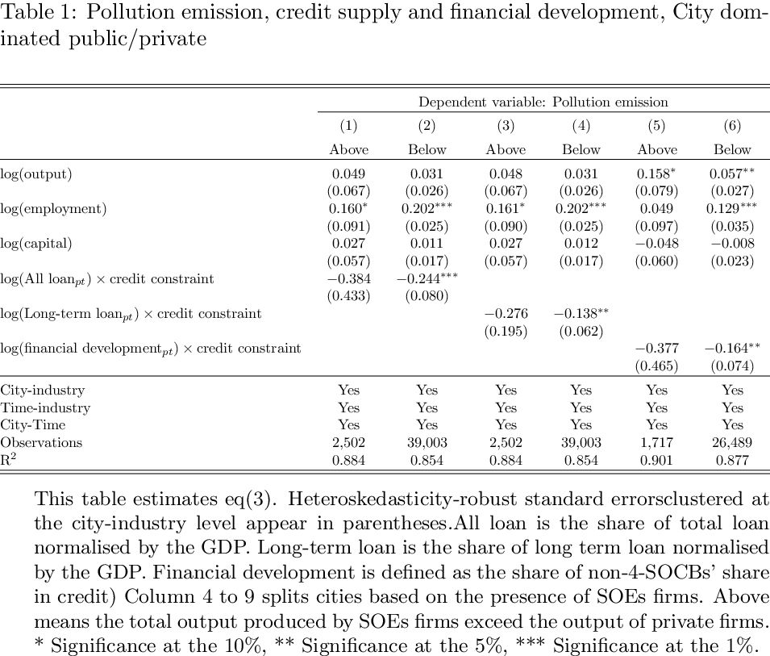

### COD

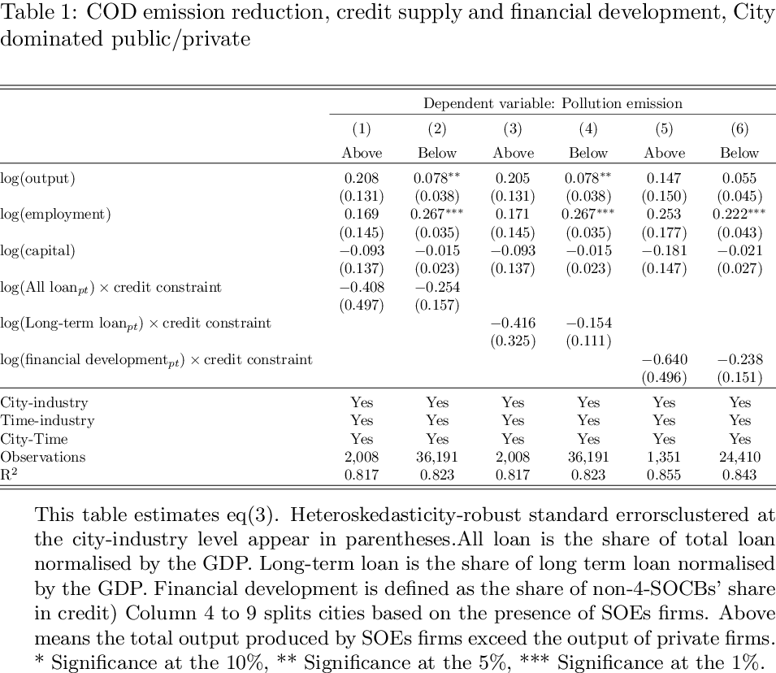

### Waste water

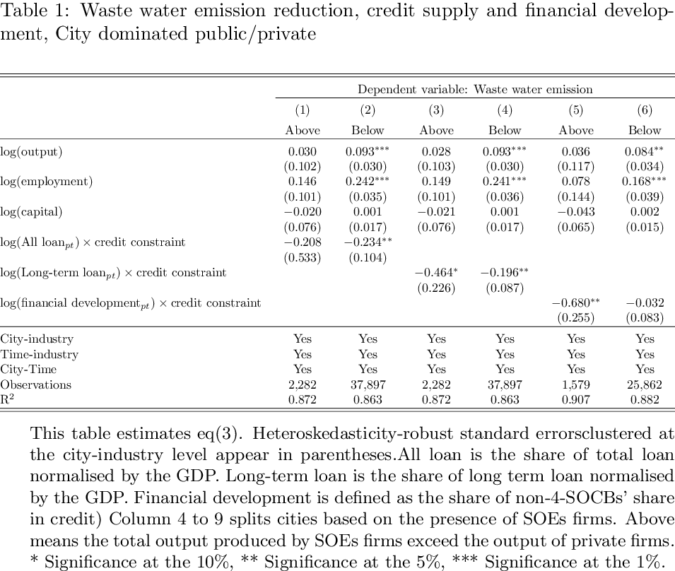

## Table 3: heterogeneous effect: Domestic vs Foreign

### SO2

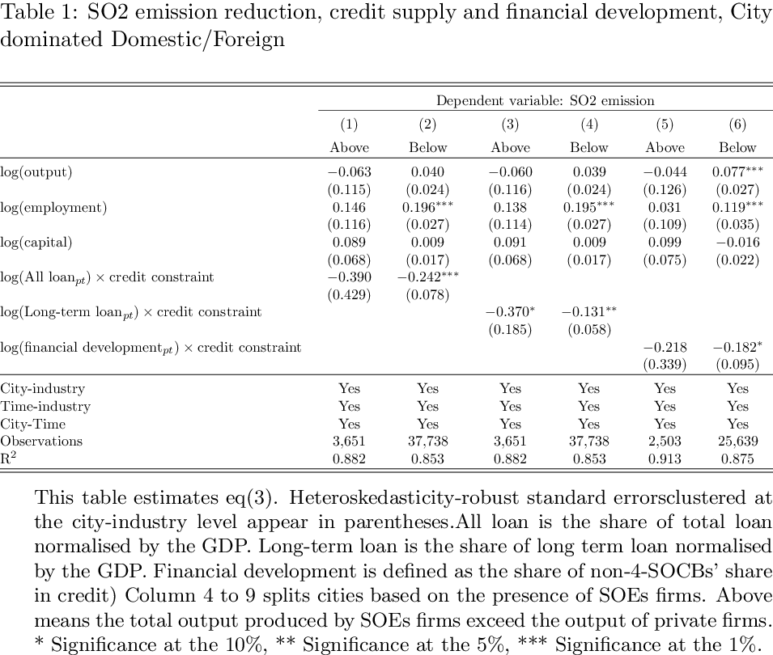

### COD

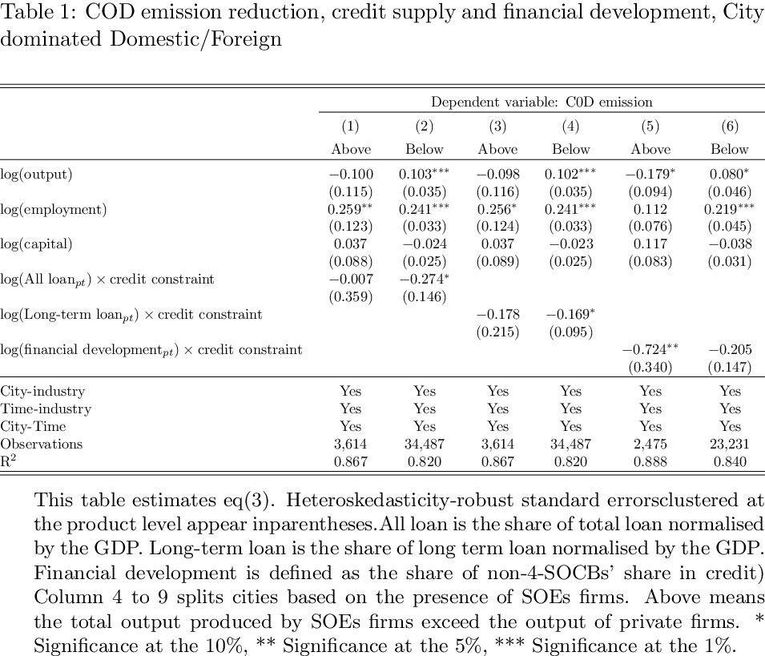

### Waste water

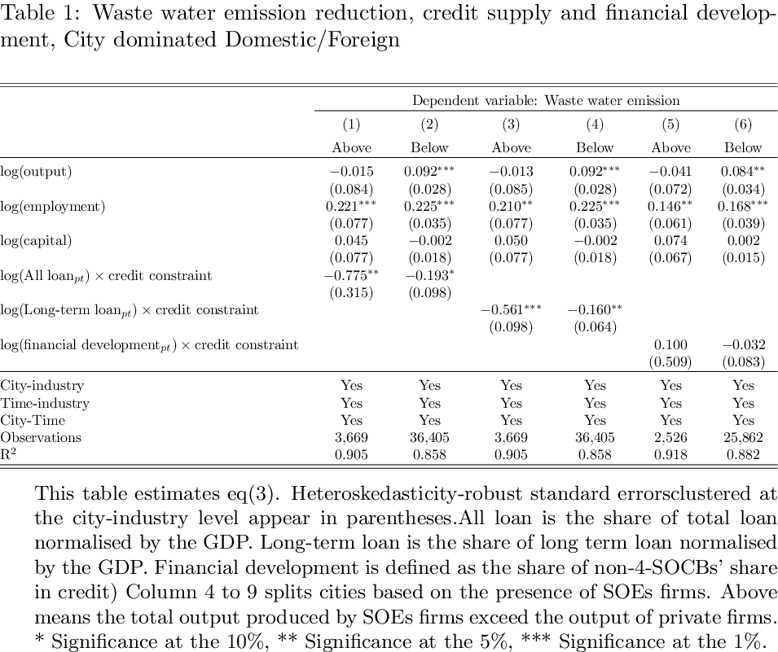

## Table 4: heterogeneous effect: Large vs Small

### SO2

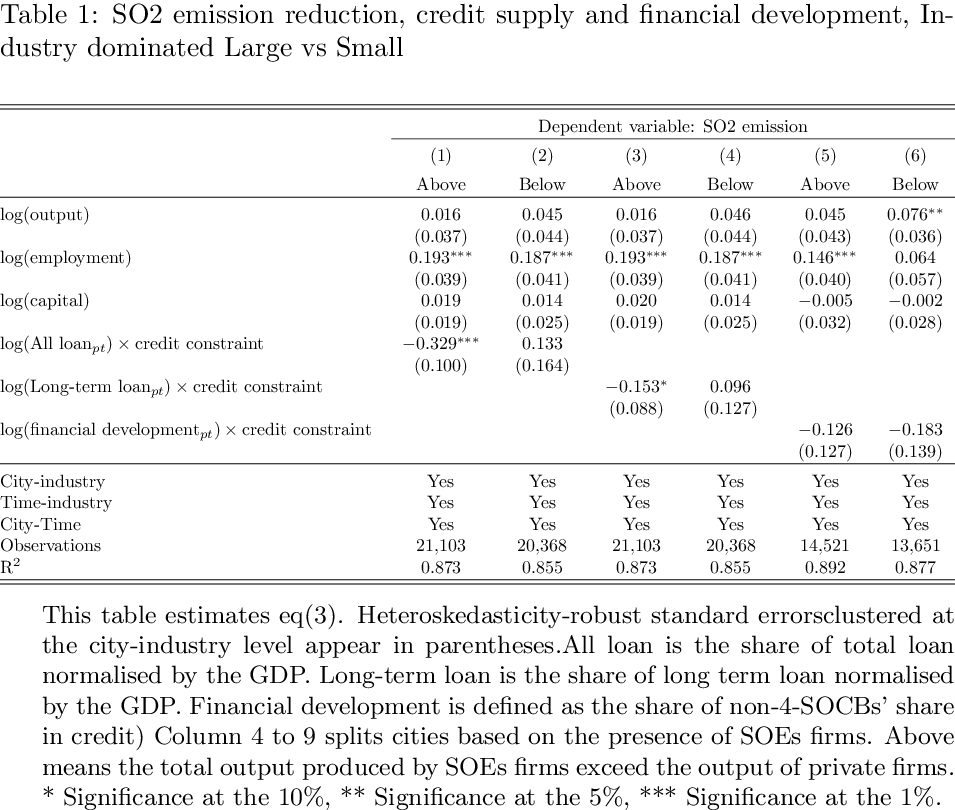

### COD

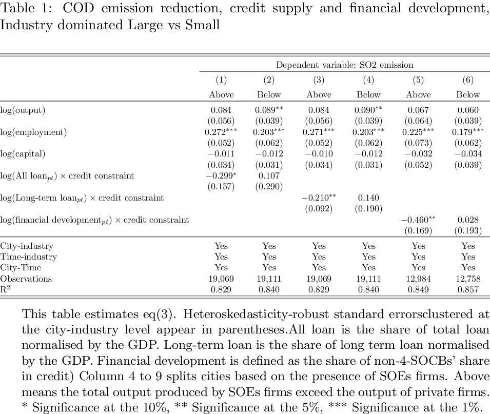

### Waste water

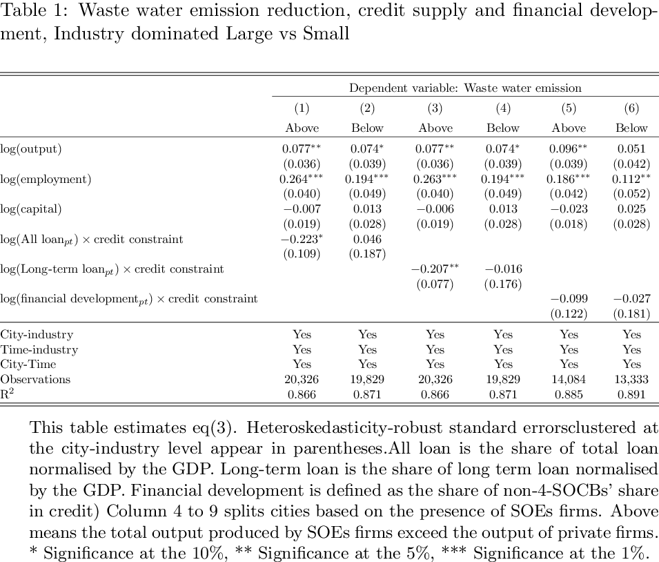

## Table 5: TCZ & SPZ policy

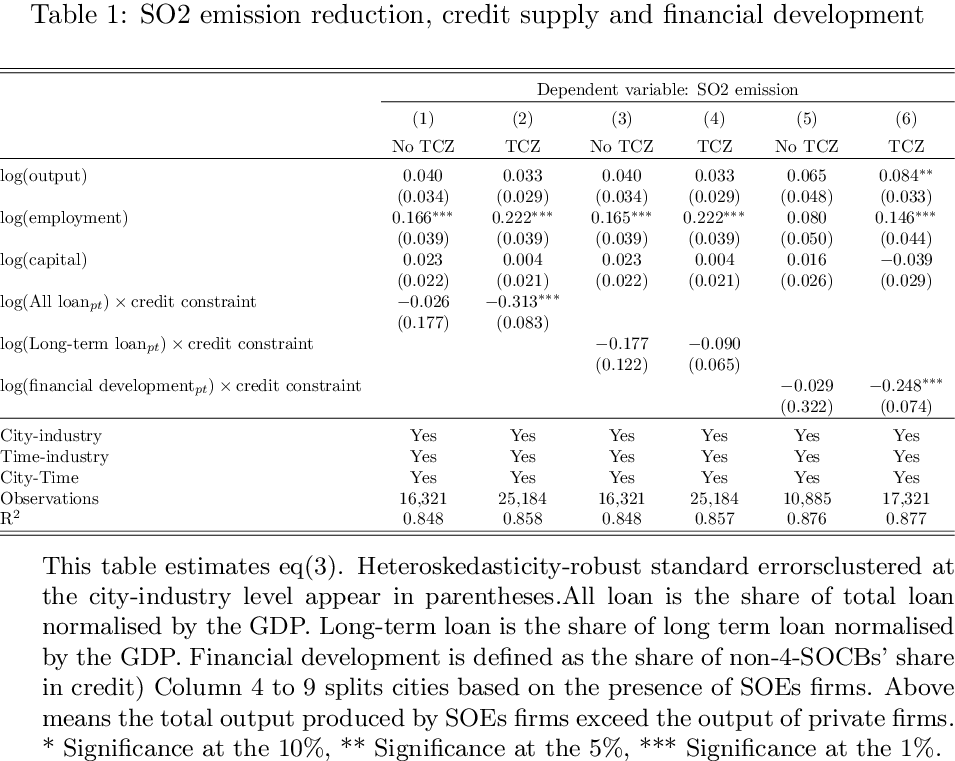

## Table 6: Environmental policy and financial development

$$ \begin{aligned} \text{$S O 2_{p k t}=\alpha$ Financial Dependencies $_{k} \times \text{credit supply}_{pt} \times \text{policy mandate}_p +\mu_{p t}+\gamma_{k t}+\delta_{p k}+\epsilon_{p k t}$} \end{aligned} $$

Environmental policy and financial development: Aggregate at the province-industry-year level

1. Evaluate the effect of credit constraint in provinces with stringent environmental policy
   1. SO2
      1. credit_constraint *target_reduction_so2_p* period
      2. lag_credit_supply*credit_constraint* target_reduction_so2_p * period
   2. ~COD~
      1. ~credit_constraint *target_reduction_co2_p* period~
      2. ~lag_credit_supply*credit_constraint* target_reduction_co2_p * period~

Message

- Capital within financially constrained industries have been relocated toward investment less harming for the environment (i.e. lower emission) in province with stringent environmental policy
- One channel is the increase of the credit access → more loan availability in constraint industry

### Province level

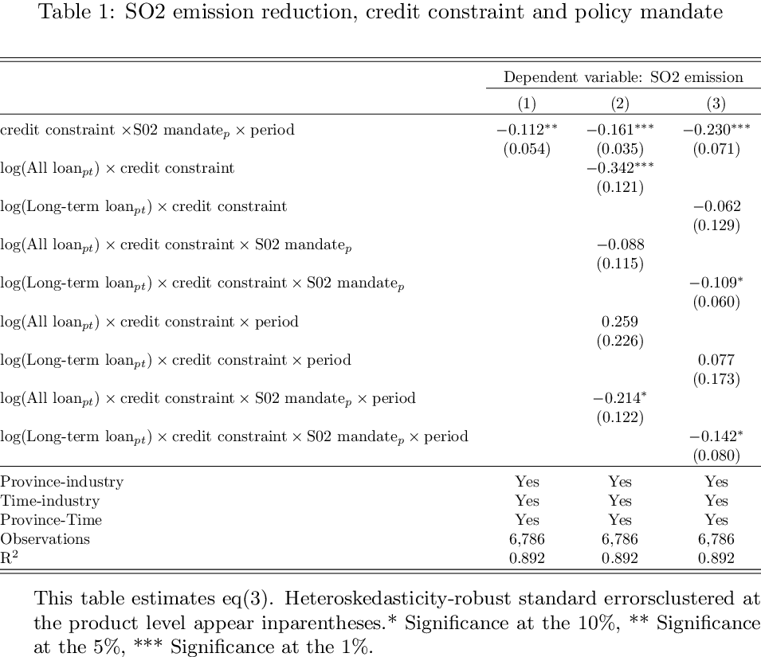

## Table 7: parallel trend

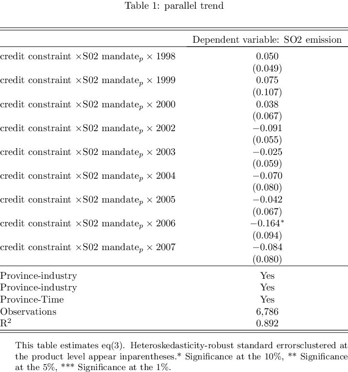

# Generate reports

```
Report Available at this adress:
 /home/ubuntu/pollution_credit_constraint/02_data_analysis/01_model_estimation/01_credit_supply/Reports/00_credit_supply.html
```